# 1000plus collateral flow & perfusion project

Ahmed Khalil

31 January, 2019

### Methods

**Reperfusion** is defined as the relative Tmax >6s change (% of baseline).  
Surrogates for good collateral flow in this study are:  
* Presence of reperfusion in non-recanalizers  
* The hypoperfusion intensity ration (HIR) at baseline (lower is better), defined according to:  
*Bang, O. Y. et al. (2008) âDeterminants of the distribution and severity of hypoperfusion in patients with ischemic stroke.â, Neurology*  
* The modified ASITN/SIR Collateral Flow Grading System (adapted for DSC-MRI, aka “Higashida score”), according to:  
*Campbell BC V, Christensen S, Tress BM, Churilov L, Desmond PM, Parsons MW, Alan Barber P, Levi CR, Bladin C, Donnan GA, Davis SM (2013) Failure of collateral blood flow is associated with infarct growth in ischemic stroke. J Cereb Blood Flow Metab*

The outcome measures in this study are:  
* Extent of reperfusion - relative Tmax >6s change (%)  
* Modified Rankin Scale at Day 90  
* Absolute infarct growth on DWI between days 1 and 2 (mL)  
* Absolute infarct growth between days 1 (DWI) and 5 (FLAIR) (mL)

All regression analyses are performed using a robust GLM (“High Breakdown And High Efficiency Robust Linear Regression”) using the R function “lmrob” from the “robustbase” package.  
Citation of package:  
*Martin Maechler, Peter Rousseeuw, Christophe Croux, Valentin Todorov, Andreas Ruckstuhl, Matias Salibian-Barrera, Tobias Verbeke, Manuel Koller, Eduardo L. T. Conceicao and Maria Anna di Palma (2018). robustbase: Basic Robust Statistics R package version 0.93-0. URL http://CRAN.R-project.org/package=robustbase*  
Citation of robust GLM:  
*Yohai, V. J. (1987). High breakdown-point and high efficiency robust estimates for regression. The Annals of Statistics, 642-656.*

**Power analysis:**

Sample size needed to detect minimum R<sup>2</sup> of 0.1 at significance level of 0.05 and power of 0.8 with 11 predictors (including interactions) = 166.0737922. Performed with the R package “pwr”.  
Citation of package:  
*Stephane Champely (2018). pwr: Basic Functions for Power Analysis. R package version 1.2-2. https://CRAN.R-project.org/package=pwr*

### Descriptive statistics

```
## Factors are dropped from the summary
```

|  | N | Missing |  | Mean | SD |  | Min | Q1 | Median | Q3 | Max |
| --- | --- | --- | --- | --- | --- | --- | --- | --- | --- | --- | --- |
| ID | 186 | 0 |  | 156.76 | 96.20 |  | 2.00 | 71.00 | 154.50 | 242.00 | 323.00 |
| age | 186 | 0 |  | 71.72 | 13.23 |  | 23.00 | 66.00 | 74.00 | 82.00 | 93.00 |
| TSI | 186 | 0 |  | 6.97 | 6.81 |  | 0.00 | 1.50 | 3.55 | 12.10 | 24.00 |
| NIHSS_ad | 186 | 0 |  | 8.28 | 6.33 |  | 0.00 | 3.00 | 6.00 | 13.00 | 25.00 |
| NIHSS_dis | 185 | 1 |  | 4.39 | 5.66 |  | 0.00 | 0.00 | 2.00 | 6.00 | 29.00 |
| mRS_ad | 176 | 10 |  | 3.03 | 1.47 |  | 0.00 | 2.00 | 3.00 | 4.00 | 5.00 |
| mRS_dis | 173 | 13 |  | 2.19 | 1.64 |  | 0.00 | 1.00 | 2.00 | 4.00 | 6.00 |
| mRS_d90 | 149 | 37 |  | 2.30 | 1.92 |  | 0.00 | 1.00 | 2.00 | 4.00 | 6.00 |
| DWIvol_d1 | 186 | 0 |  | 15.26 | 27.48 |  | 0.00 | 0.99 | 5.40 | 18.55 | 231.36 |
| DWIvol_d2 | 186 | 0 |  | 31.18 | 49.31 |  | 0.00 | 3.07 | 12.39 | 39.64 | 324.01 |
| Tmax_vol_d1 | 186 | 0 |  | 45.47 | 49.77 |  | 0.00 | 11.00 | 26.60 | 67.00 | 258.63 |
| Tmax_vol_d2 | 186 | 0 |  | 26.83 | 85.47 |  | 0.00 | 1.00 | 7.00 | 27.50 | 1094.00 |
| DWIgrowth | 186 | 0 |  | 15.91 | 28.08 |  | -1.34 | 0.72 | 5.28 | 14.74 | 178.68 |
| rel_DWIgrowth | 186 | 0 |  | 357.66 | 1268.39 |  | -100.00 | 30.46 | 72.54 | 210.90 | 11561.11 |
| Tmax_change | 186 | 0 |  | -23.94 | 42.72 |  | -258.63 | -37.00 | -9.50 | -1.00 | 104.80 |
| relTmax_change | 186 | 0 |  | -29.35 | 143.98 |  | -100.00 | -95.56 | -57.30 | -7.69 | 1433.33 |
| mismatch_vol | 186 | 0 |  | 30.21 | 47.59 |  | -119.36 | 0.84 | 16.76 | 53.16 | 253.40 |
| infarct_growth_D5FLAIR | 141 | 45 |  | 26.87 | 43.08 |  | -3.68 | 1.97 | 8.50 | 29.69 | 222.72 |
| FLAIR_d5_vol | 141 | 45 |  | 41.57 | 57.20 |  | 0.01 | 5.90 | 18.50 | 55.50 | 300.40 |
| Tmax_D1_.2_volume | 186 | 0 |  | 83.28 | 60.82 |  | 1.05 | 33.30 | 72.75 | 120.61 | 317.11 |
| Tmax_D1_.4_volume | 186 | 0 |  | 64.04 | 57.58 |  | 0.14 | 19.03 | 46.88 | 93.02 | 317.11 |
| Tmax_D1_.8_volume | 186 | 0 |  | 27.50 | 34.79 |  | 0.00 | 2.82 | 12.70 | 38.68 | 172.25 |
| Tmax_D2_.2_volume | 186 | 0 |  | 48.02 | 53.07 |  | 0.00 | 8.02 | 30.91 | 62.36 | 281.54 |
| Tmax_D2_.4_volume | 186 | 0 |  | 32.84 | 44.49 |  | 0.00 | 2.41 | 16.44 | 40.61 | 226.83 |
| Tmax_D2_.8_volume | 186 | 0 |  | 11.60 | 21.45 |  | 0.00 | 0.08 | 1.62 | 14.76 | 130.90 |
| HIR1 | 186 | 0 |  | 0.27 | 0.24 |  | 0.00 | 0.07 | 0.23 | 0.42 | 1.00 |
| HIR2 | 178 | 8 |  | 0.18 | 0.24 |  | 0.00 | 0.01 | 0.07 | 0.29 | 1.00 |
| Tmax_D1_.6_volume | 186 | 0 |  | 45.47 | 49.77 |  | 0.00 | 11.00 | 26.60 | 67.00 | 258.63 |
| Tmax_D2_.6_volume | 186 | 0 |  | 26.83 | 85.47 |  | 0.00 | 1.00 | 7.00 | 27.50 | 1094.00 |
| Tmax_6_reperf_abs | 186 | 0 |  | 18.64 | 84.23 |  | -966.10 | 1.00 | 9.00 | 37.00 | 258.63 |
| Tmax_6_reperf_rel | 180 | 6 |  | 26.05 | 157.55 |  | -1433.33 | 11.09 | 66.18 | 96.09 | 100.00 |

```
           Level               N  %
```

### Predictors of extent of reperfusion

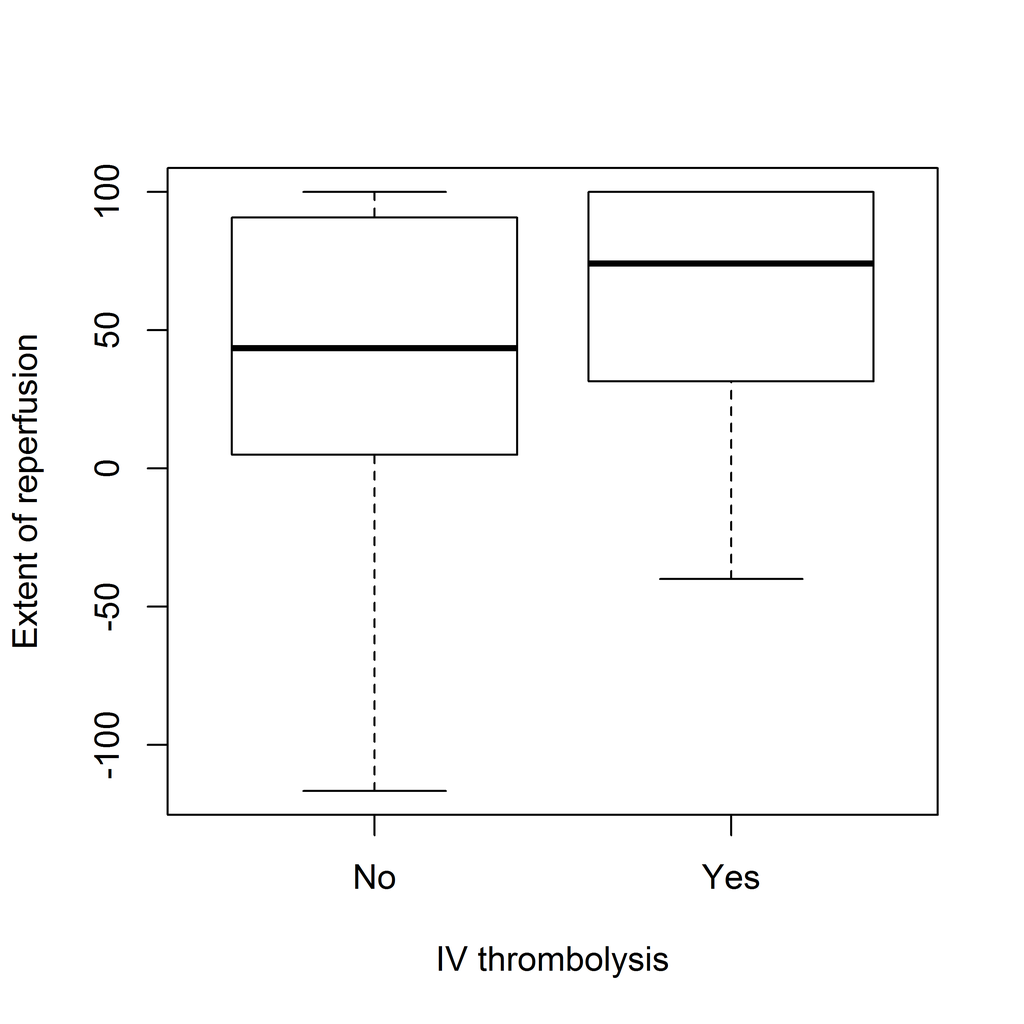

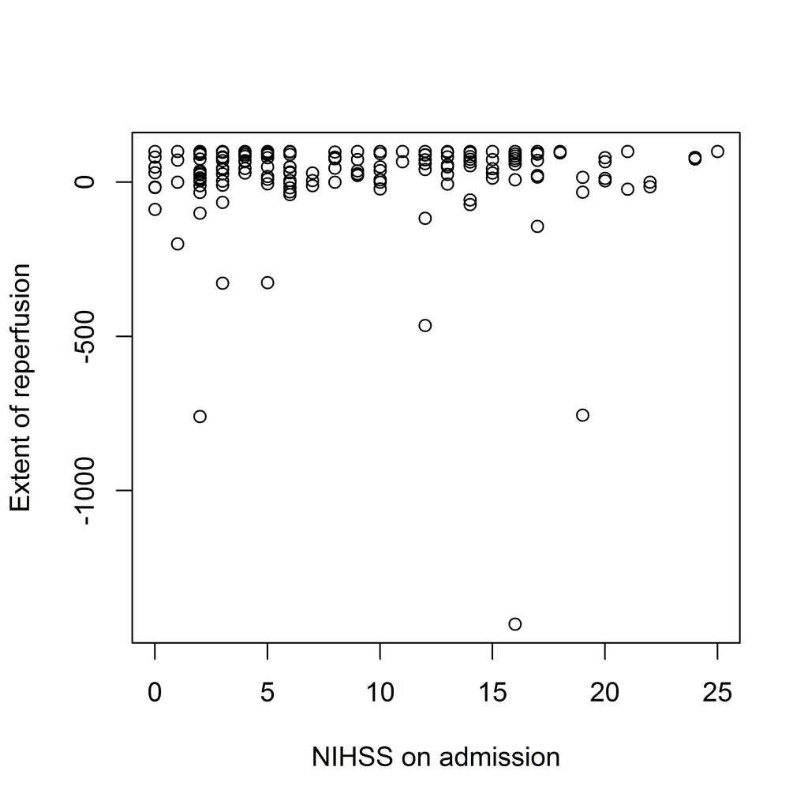

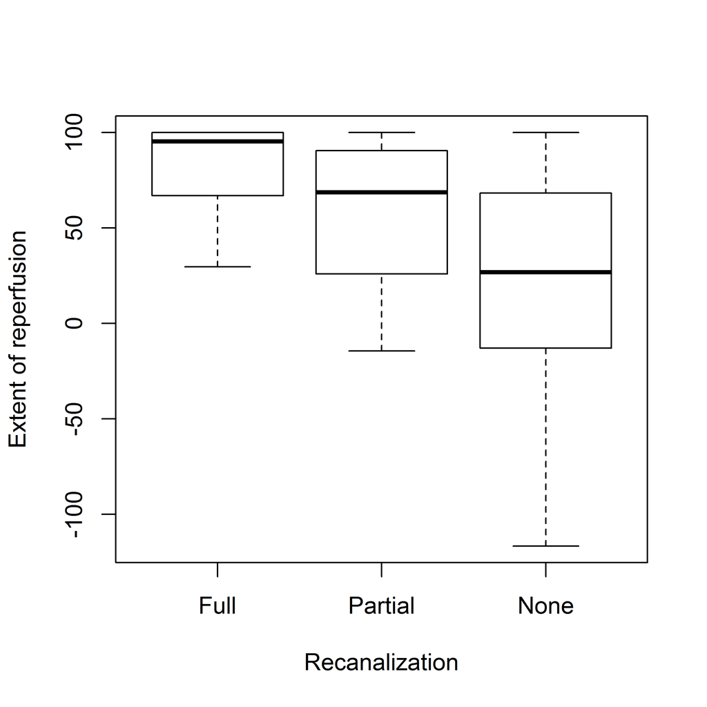

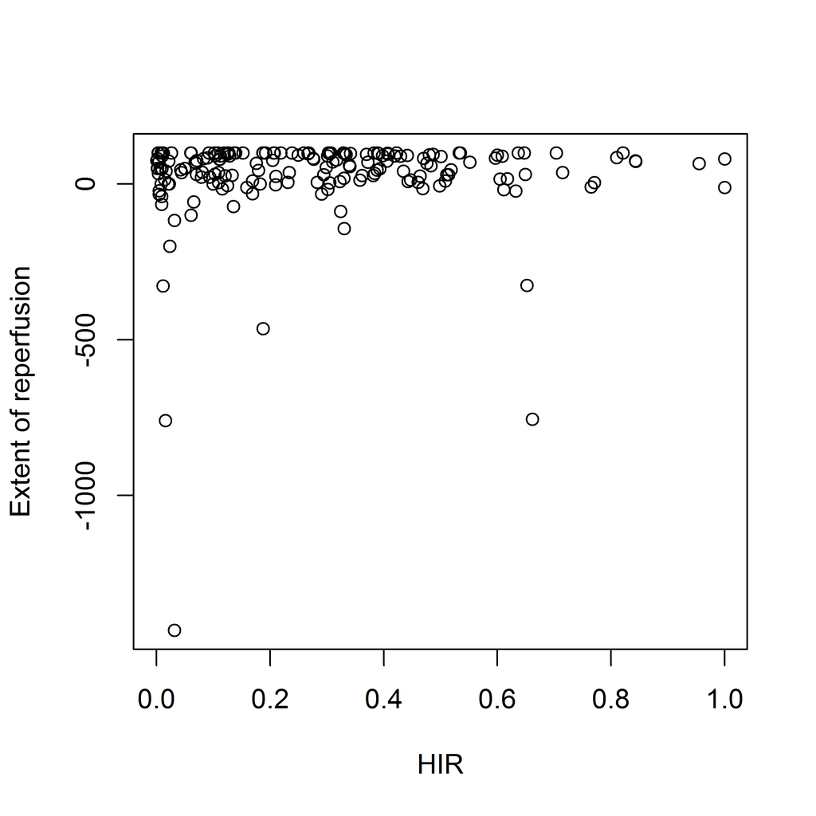

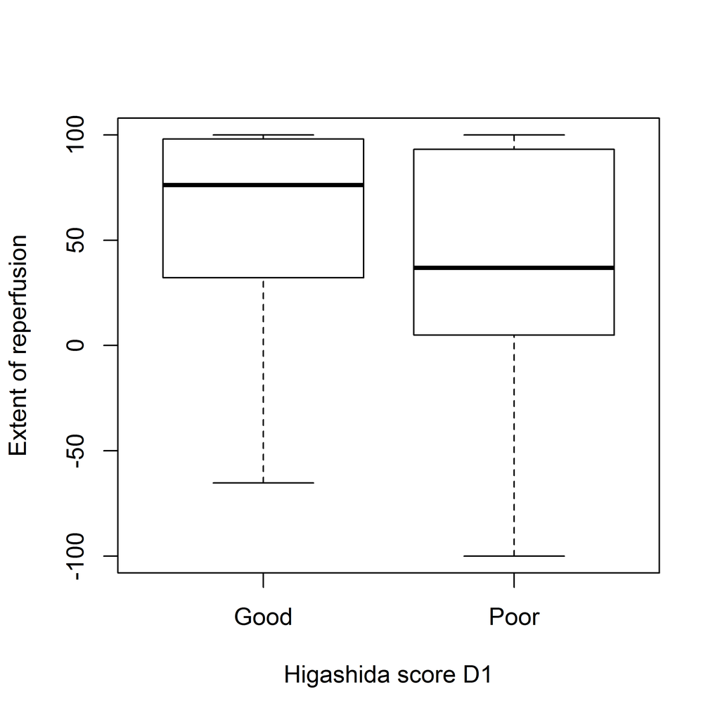

|  | *Dependent variable:* |  |  |  |
| --- | --- | --- | --- | --- |
|  | Tmax_6_reperf_rel |  |  |  |
|  | (1) | (2) | (3) | (4) |
| NIHSS_ad | -0.248 (0.575) | 0.038 (0.535) | 0.124 (0.576) | 0.442 (0.513) |
|  | t = -0.431 | t = 0.072 | t = 0.214 | t = 0.861 |
|  | p = 0.668 | p = 0.944 | p = 0.831 | p = 0.391 |
| iv_tPRYes | 17.504** (7.249) | 6.436 (7.112) | 6.636 (7.120) | 8.281 (6.605) |
|  | t = 2.415 | t = 0.905 | t = 0.932 | t = 1.254 |
|  | p = 0.017 | p = 0.367 | p = 0.353 | p = 0.212 |
| HIR1 |  |  | -5.635 (15.033) |  |
|  |  |  | t = -0.375 |  |
|  |  |  | p = 0.709 |  |
| higashida_D1_binPoor |  |  |  | -22.765*** (6.178) |
|  |  |  |  | t = -3.685 |
|  |  |  |  | p = 0.0004 |
| RekanPartial |  | -17.636** (8.152) | -17.835** (8.150) | -21.422*** (7.603) |
|  |  | t = -2.163 | t = -2.188 | t = -2.818 |
|  |  | p = 0.032 | p = 0.030 | p = 0.006 |
| RekanNone |  | -45.205*** (8.335) | -45.332*** (8.333) | -44.529*** (7.746) |
|  |  | t = -5.423 | t = -5.440 | t = -5.749 |
|  |  | p = 0.00000 | p = 0.00000 | p = 0.00000 |
| Constant | 50.924*** (6.084) | 75.110*** (7.802) | 76.098*** (8.199) | 83.318*** (7.496) |
|  | t = 8.370 | t = 9.628 | t = 9.281 | t = 11.114 |
|  | p = 0.000 | p = 0.000 | p = 0.000 | p = 0.000 |
| Observations | 180 | 180 | 180 | 180 |
| R<sup>2</sup> | 0.032 | 0.182 | 0.184 | 0.245 |
| Adjusted R<sup>2</sup> | 0.021 | 0.164 | 0.160 | 0.224 |
| Residual Std. Error | 46.272 (df = 177) | 42.041 (df = 175) | 42.017 (df = 174) | 39.673 (df = 174) |
| *Note:* | p<0.1; p<0.05; p<0.01 |  |  |  |

**1 vs 2**

| Statistic | N | Mean | St. Dev. | Min | Max |
| --- | --- | --- | --- | --- | --- |
| pseudoDf | 2 | 176.000 | 1.414 | 175 | 177 |
| Test.Stat | 1 | 30.672 |  | 30.672 | 30.672 |
| Df | 1 | 2.000 |  | 2 | 2 |
| Pr(> chisq) | 1 | 0.00000 |  | 0.00000 | 0.00000 |

**1 vs 3**

| Statistic | N | Mean | St. Dev. | Min | Max |
| --- | --- | --- | --- | --- | --- |
| pseudoDf | 2 | 175.500 | 2.121 | 174 | 177 |
| Test.Stat | 1 | 30.855 |  | 30.855 | 30.855 |
| Df | 1 | 3.000 |  | 3 | 3 |
| Pr(> chisq) | 1 | 0.00000 |  | 0.00000 | 0.00000 |

**1 vs 4**

| Statistic | N | Mean | St. Dev. | Min | Max |
| --- | --- | --- | --- | --- | --- |
| pseudoDf | 2 | 175.500 | 2.121 | 174 | 177 |
| Test.Stat | 1 | 48.052 |  | 48.052 | 48.052 |
| Df | 1 | 3.000 |  | 3 | 3 |
| Pr(> chisq) | 1 | 0.000 |  | 0 | 0 |

#### Predictors of extent of reperfusion in non-recanalizers

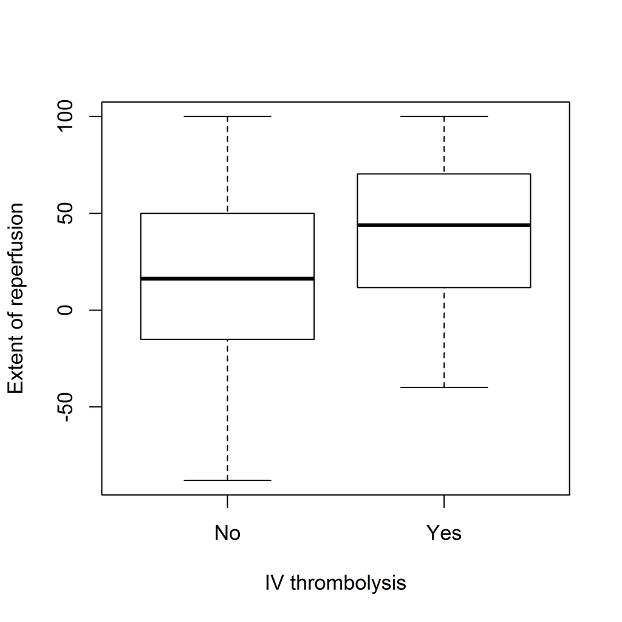

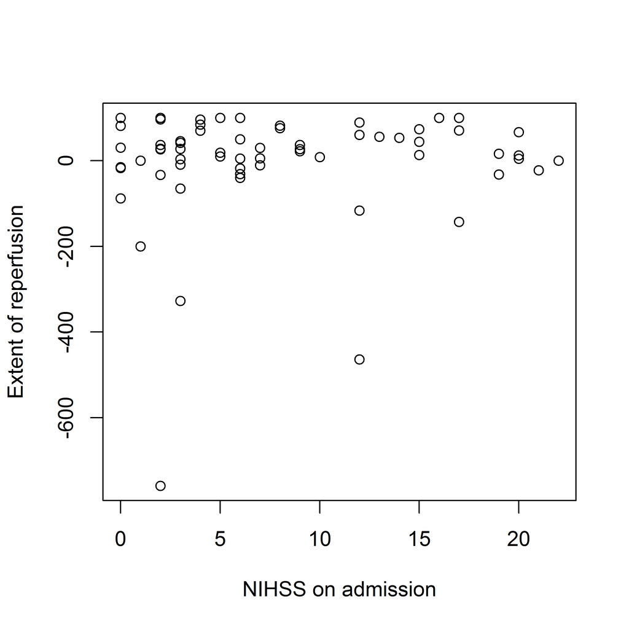

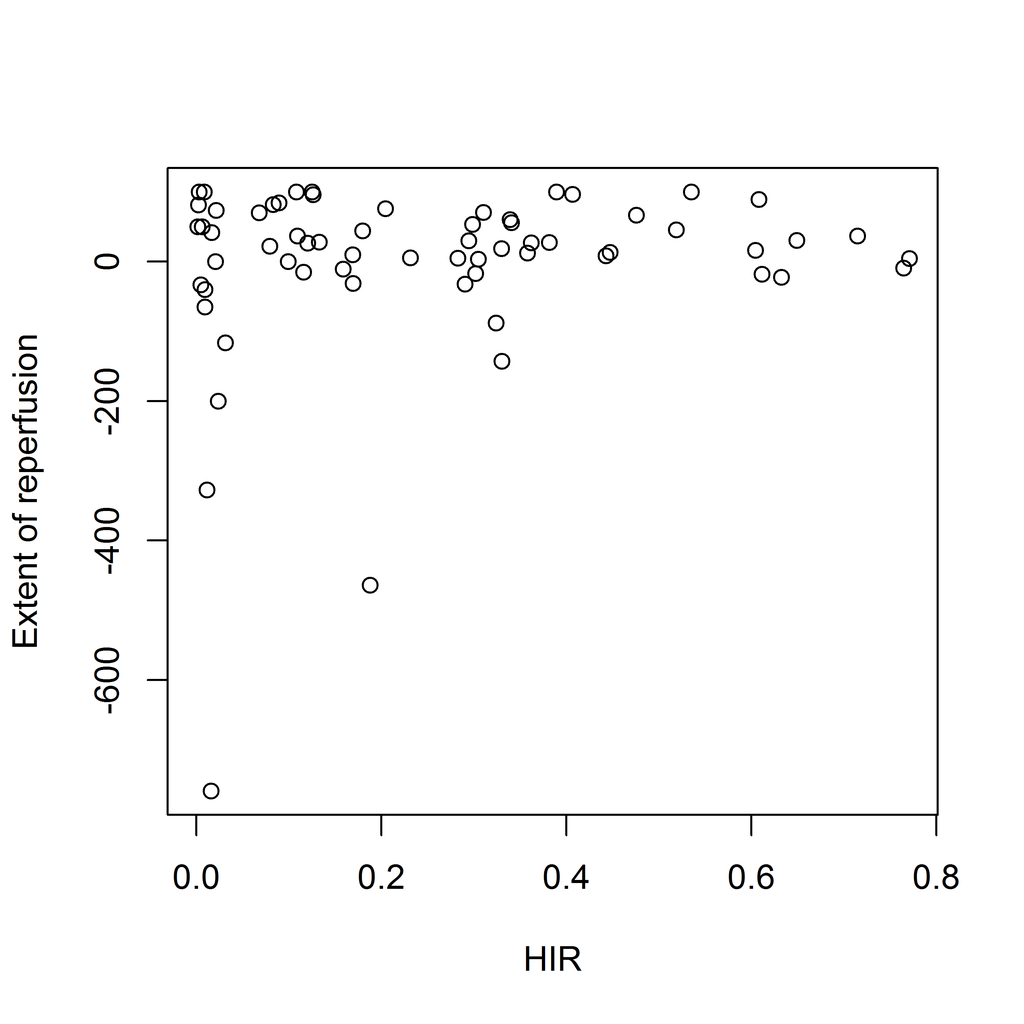

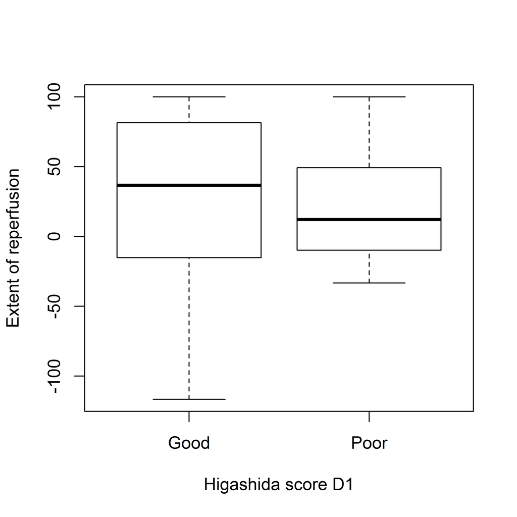

|  | *Dependent variable:* |  |  |
| --- | --- | --- | --- |
|  | Tmax_6_reperf_rel |  |  |
|  | (1) | (2) | (3) |
| NIHSS_ad | -0.392 (1.111) | -0.204 (1.175) | 0.019 (1.085) |
|  | t = -0.352 | t = -0.174 | t = 0.018 |
|  | p = 0.726 | p = 0.863 | p = 0.986 |
| iv_tPRYes | 19.696 (15.706) | 19.043 (15.728) | 20.046 (14.721) |
|  | t = 1.254 | t = 1.211 | t = 1.362 |
|  | p = 0.215 | p = 0.231 | p = 0.179 |
| HIR1 |  | -15.750 (32.473) |  |
|  |  | t = -0.485 |  |
|  |  | p = 0.630 |  |
| higashida_D1_binPoor |  |  | -21.902 (13.171) |
|  |  |  | t = -1.663 |
|  |  |  | p = 0.102 |
| Constant | 27.679** (10.819) | 30.728** (12.296) | 36.255*** (10.931) |
|  | t = 2.558 | t = 2.499 | t = 3.317 |
|  | p = 0.014 | p = 0.016 | p = 0.002 |
| Observations | 64 | 64 | 64 |
| R<sup>2</sup> | 0.026 | 0.030 | 0.069 |
| Adjusted R<sup>2</sup> | -0.006 | -0.019 | 0.023 |
| Residual Std. Error | 53.078 (df = 61) | 53.265 (df = 60) | 50.692 (df = 60) |
| *Note:* | p<0.1; p<0.05; p<0.01 |  |  |

**1 vs 2**

| Statistic | N | Mean | St. Dev. | Min | Max |
| --- | --- | --- | --- | --- | --- |
| pseudoDf | 2 | 60.500 | 0.707 | 60 | 61 |
| Test.Stat | 1 | 0.235 |  | 0.235 | 0.235 |
| Df | 1 | 1.000 |  | 1 | 1 |
| Pr(> chisq) | 1 | 0.628 |  | 0.628 | 0.628 |

**1 vs 3**

| Statistic | N | Mean | St. Dev. | Min | Max |
| --- | --- | --- | --- | --- | --- |
| pseudoDf | 2 | 60.500 | 0.707 | 60 | 61 |
| Test.Stat | 1 | 2.765 |  | 2.765 | 2.765 |
| Df | 1 | 1.000 |  | 1 | 1 |
| Pr(> chisq) | 1 | 0.096 |  | 0.096 | 0.096 |

#### Predictors of extent of reperfusion in recanalizers

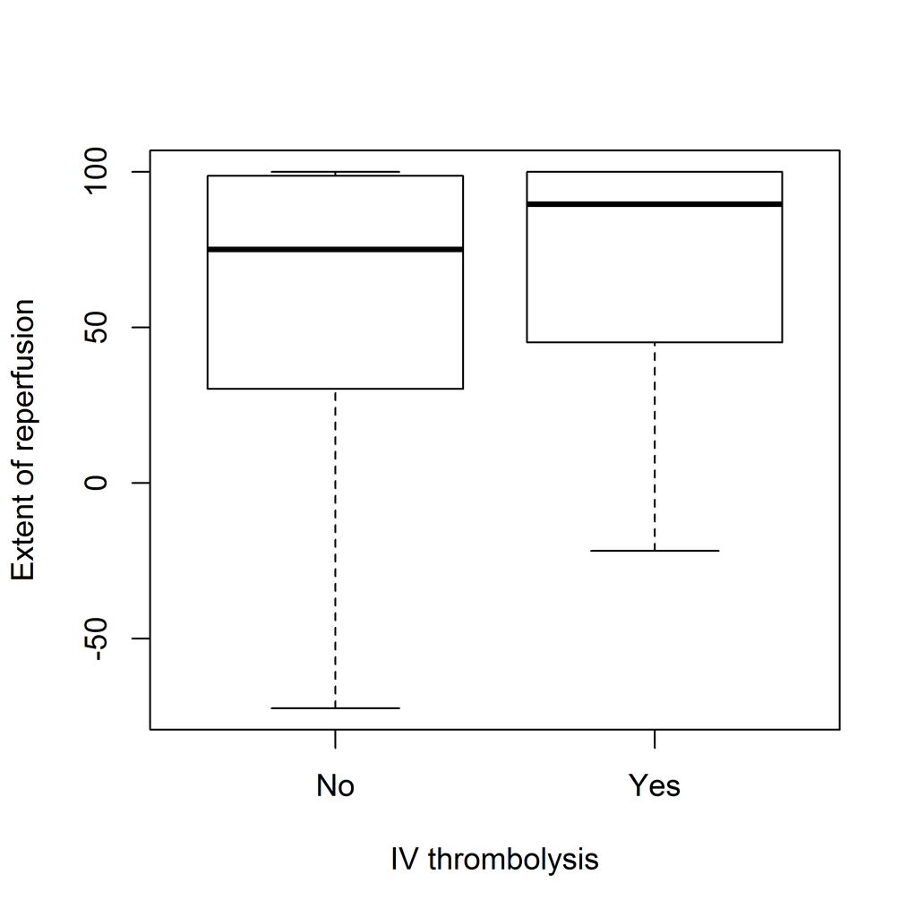

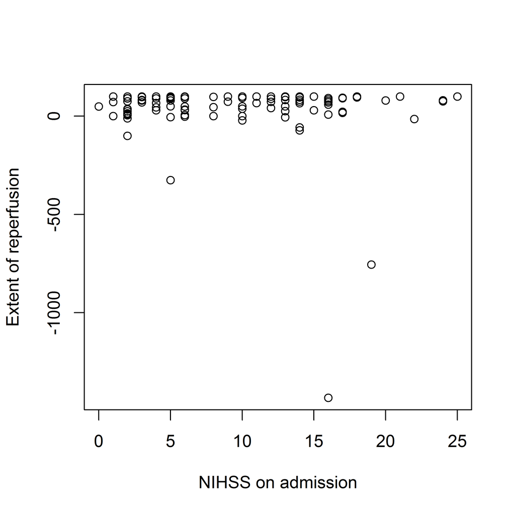

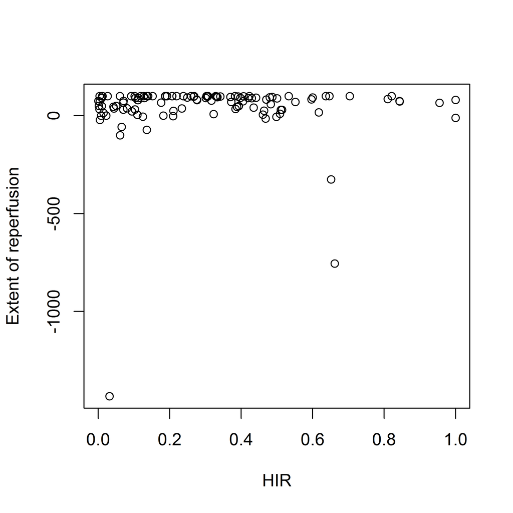

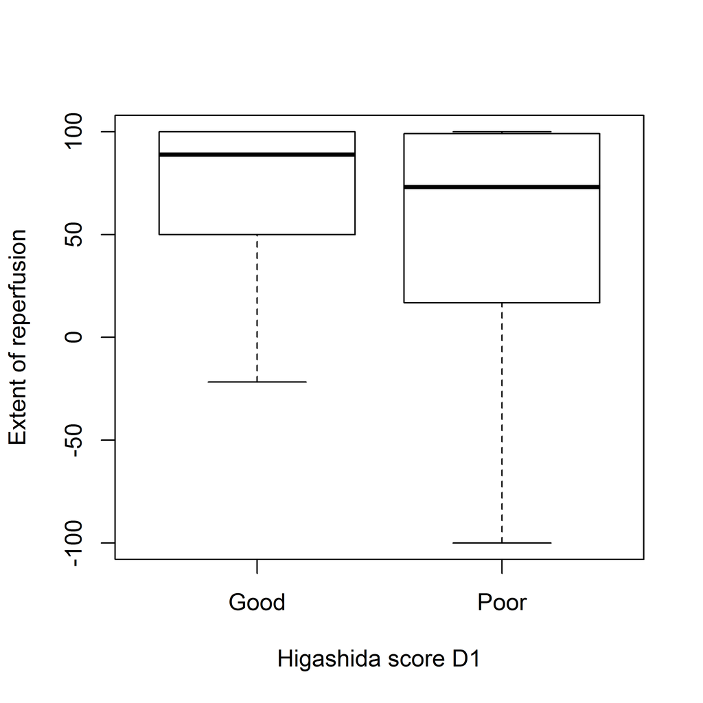

|  | *Dependent variable:* |  |  |
| --- | --- | --- | --- |
|  | Tmax_6_reperf_rel |  |  |
|  | (1) | (2) | (3) |
| NIHSS_ad | 0.026 (0.598) | -0.139 (0.662) | 0.300 (0.600) |
|  | t = 0.043 | t = -0.210 | t = 0.501 |
|  | p = 0.966 | p = 0.835 | p = 0.618 |
| iv_tPRYes | 6.613 (7.393) | 5.873 (7.560) | 9.514 (7.297) |
|  | t = 0.894 | t = 0.777 | t = 1.304 |
|  | p = 0.373 | p = 0.439 | p = 0.195 |
| HIR1 |  | 9.230 (17.192) |  |
|  |  | t = 0.537 |  |
|  |  | p = 0.593 |  |
| higashida_D1_binPoor |  |  | -17.163** (7.299) |
|  |  |  | t = -2.352 |
|  |  |  | p = 0.021 |
| Constant | 66.575*** (6.592) | 65.534*** (6.967) | 70.256*** (6.687) |
|  | t = 10.099 | t = 9.406 | t = 10.506 |
|  | p = 0.000 | p = 0.000 | p = 0.000 |
| Observations | 116 | 116 | 116 |
| R<sup>2</sup> | 0.008 | 0.010 | 0.056 |
| Adjusted R<sup>2</sup> | -0.010 | -0.017 | 0.030 |
| Residual Std. Error | 38.275 (df = 113) | 38.540 (df = 112) | 37.582 (df = 112) |
| *Note:* | p<0.1; p<0.05; p<0.01 |  |  |

**1 vs 2**

| Statistic | N | Mean | St. Dev. | Min | Max |
| --- | --- | --- | --- | --- | --- |
| pseudoDf | 2 | 112.500 | 0.707 | 112 | 113 |
| Test.Stat | 1 | 0.288 |  | 0.288 | 0.288 |
| Df | 1 | 1.000 |  | 1 | 1 |
| Pr(> chisq) | 1 | 0.591 |  | 0.591 | 0.591 |

**1 vs 3**

| Statistic | N | Mean | St. Dev. | Min | Max |
| --- | --- | --- | --- | --- | --- |
| pseudoDf | 2 | 112.500 | 0.707 | 112 | 113 |
| Test.Stat | 1 | 5.530 |  | 5.530 | 5.530 |
| Df | 1 | 1.000 |  | 1 | 1 |
| Pr(> chisq) | 1 | 0.019 |  | 0.019 | 0.019 |

### Predictors of clinical outcome

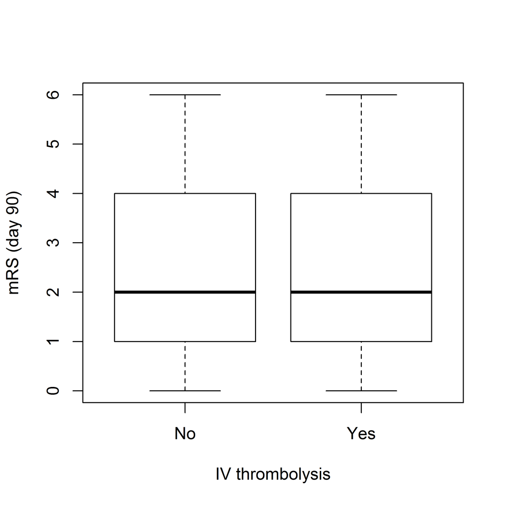

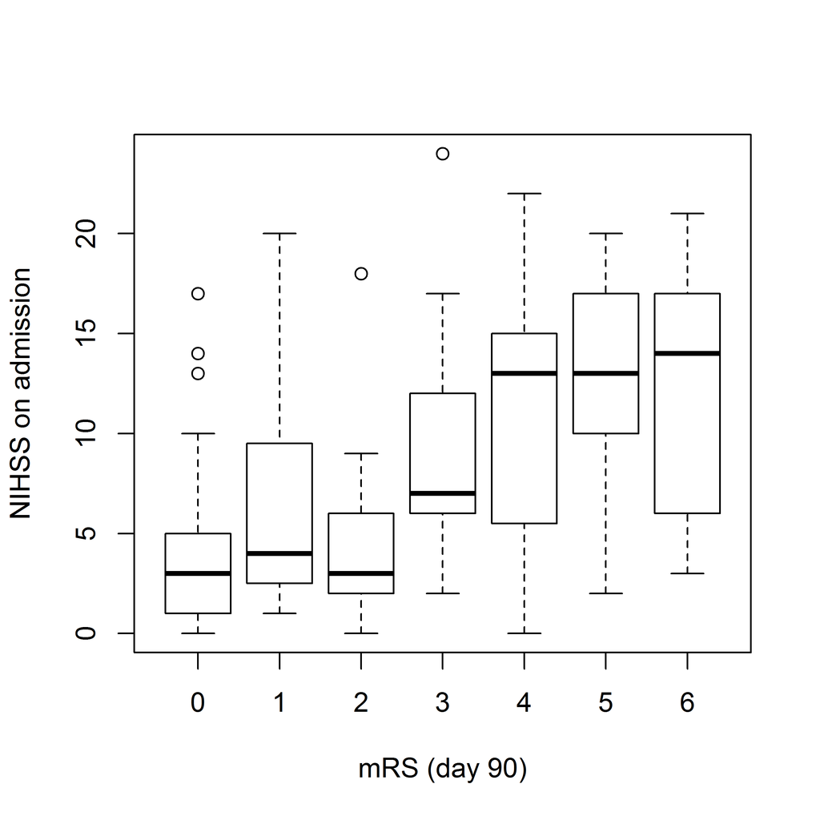

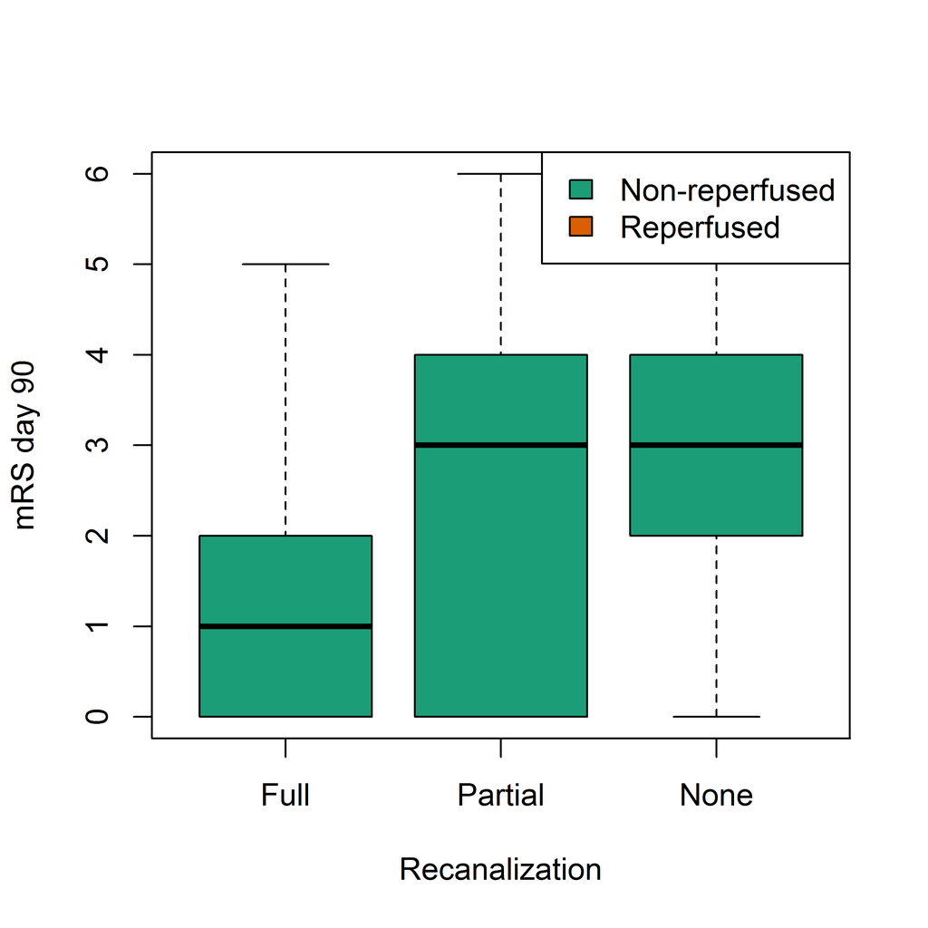

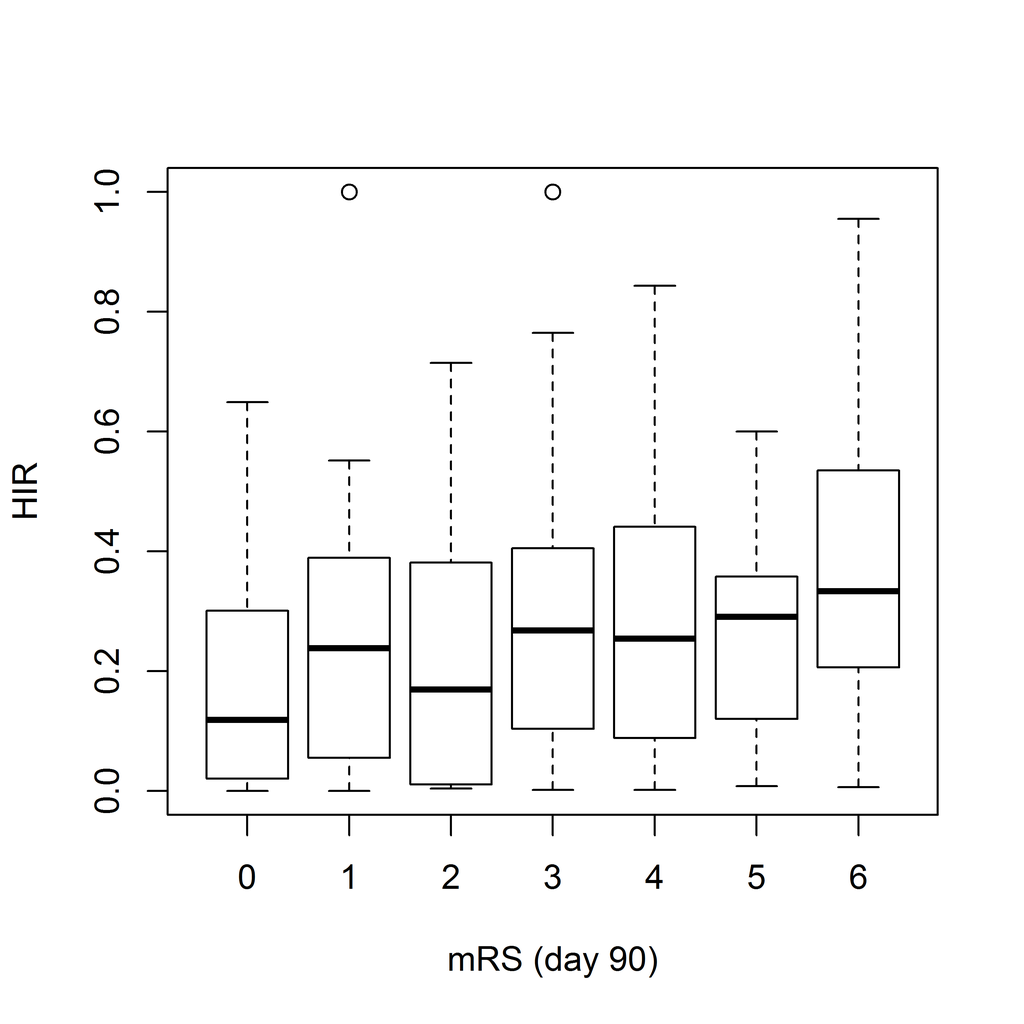

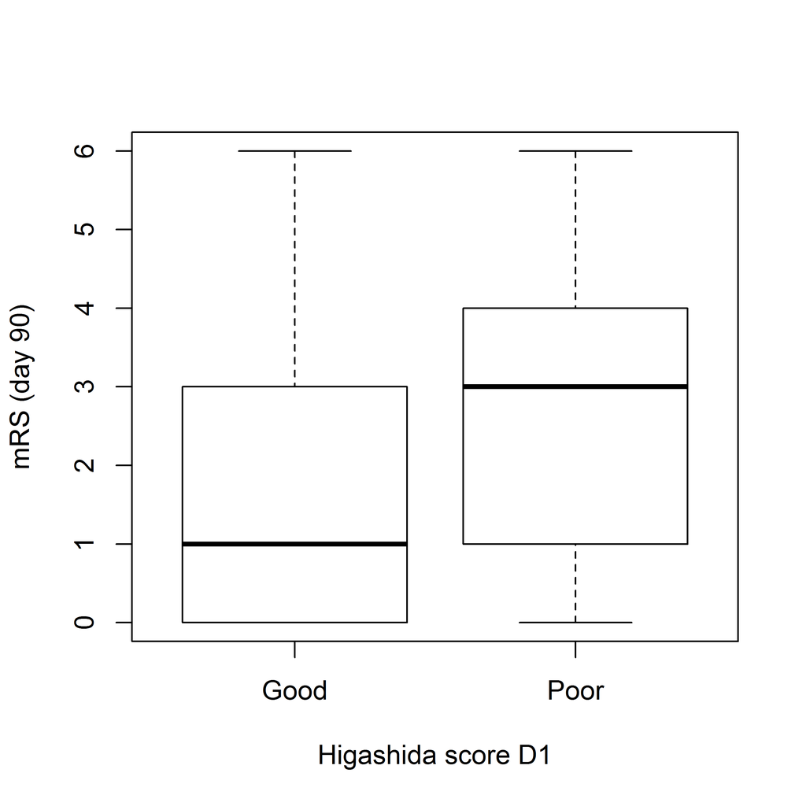

|  | *Dependent variable:* |  |  |  |
| --- | --- | --- | --- | --- |
|  | mRS_d90 |  |  |  |
|  | (1) | (2) | (3) | (4) |
| NIHSS_ad | 0.174*** (0.025) | 0.164*** (0.024) | 0.154*** (0.026) | 0.157*** (0.025) |
|  | t = 6.941 | t = 6.800 | t = 6.045 | t = 6.165 |
|  | p = 0.000 | p = 0.000 | p = 0.000 | p = 0.000 |
| iv_tPRYes | -0.777** (0.307) | -0.563* (0.306) | -0.574* (0.307) | -0.582* (0.308) |
|  | t = -2.526 | t = -1.839 | t = -1.873 | t = -1.891 |
|  | p = 0.013 | p = 0.069 | p = 0.064 | p = 0.061 |
| RekanPartial |  | 0.381 (0.357) | 0.380 (0.358) | 0.393 (0.359) |
|  |  | t = 1.066 | t = 1.063 | t = 1.095 |
|  |  | p = 0.289 | p = 0.290 | p = 0.276 |
| RekanNone |  | 1.454*** (0.371) | 1.467*** (0.371) | 1.438*** (0.372) |
|  |  | t = 3.921 | t = 3.951 | t = 3.866 |
|  |  | p = 0.0002 | p = 0.0002 | p = 0.0002 |
| Tmax_6_reperf_rel |  | -0.001 (0.001) | -0.001 (0.001) | -0.001 (0.001) |
|  |  | t = -0.528 | t = -0.608 | t = -0.427 |
|  |  | p = 0.599 | p = 0.545 | p = 0.671 |
| HIR1 |  |  | 0.799 (0.653) |  |
|  |  |  | t = 1.224 |  |
|  |  |  | p = 0.224 |  |
| higashida_D1_binPoor |  |  |  | 0.258 (0.296) |
|  |  |  |  | t = 0.873 |
|  |  |  |  | p = 0.385 |
| Constant | 1.243*** (0.240) | 0.631* (0.340) | 0.506 (0.355) | 0.580* (0.347) |
|  | t = 5.174 | t = 1.859 | t = 1.424 | t = 1.670 |
|  | p = 0.00000 | p = 0.066 | p = 0.157 | p = 0.098 |
| Observations | 149 | 144 | 144 | 144 |
| R<sup>2</sup> | 0.257 | 0.353 | 0.360 | 0.355 |
| Adjusted R<sup>2</sup> | 0.247 | 0.330 | 0.332 | 0.326 |
| Residual Std. Error | 1.711 (df = 146) | 1.594 (df = 138) | 1.593 (df = 137) | 1.599 (df = 137) |
| *Note:* | p<0.1; p<0.05; p<0.01 |  |  |  |

**1 vs 2**

| Statistic | N | Mean | St. Dev. | Min | Max |
| --- | --- | --- | --- | --- | --- |
| pseudoDf | 2 | 139.500 | 2.121 | 138 | 141 |
| Test.Stat | 1 | 21.412 |  | 21.412 | 21.412 |
| Df | 1 | 3.000 |  | 3 | 3 |
| Pr(> chisq) | 1 | 0.0001 |  | 0.0001 | 0.0001 |

**1 vs 3**

| Statistic | N | Mean | St. Dev. | Min | Max |
| --- | --- | --- | --- | --- | --- |
| pseudoDf | 2 | 139.000 | 2.828 | 137 | 141 |
| Test.Stat | 1 | 22.838 |  | 22.838 | 22.838 |
| Df | 1 | 4.000 |  | 4 | 4 |
| Pr(> chisq) | 1 | 0.0001 |  | 0.0001 | 0.0001 |

**1 vs 4**

| Statistic | N | Mean | St. Dev. | Min | Max |
| --- | --- | --- | --- | --- | --- |
| pseudoDf | 2 | 139.000 | 2.828 | 137 | 141 |
| Test.Stat | 1 | 22.031 |  | 22.031 | 22.031 |
| Df | 1 | 4.000 |  | 4 | 4 |
| Pr(> chisq) | 1 | 0.0002 |  | 0.0002 | 0.0002 |

### Predictors of absolute infarct growth (D1 - D2)

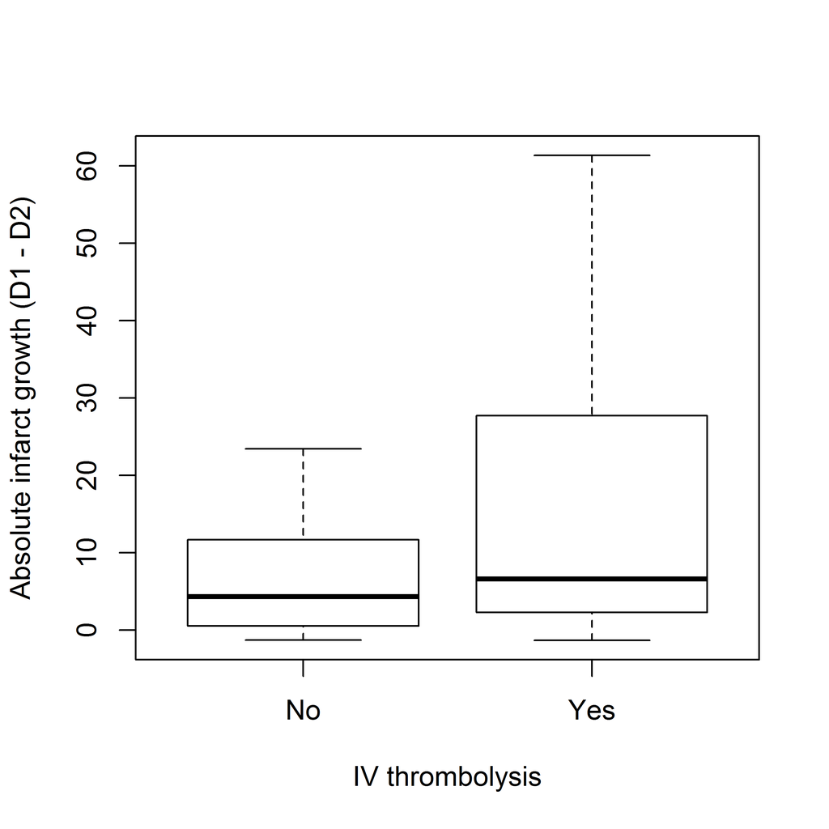

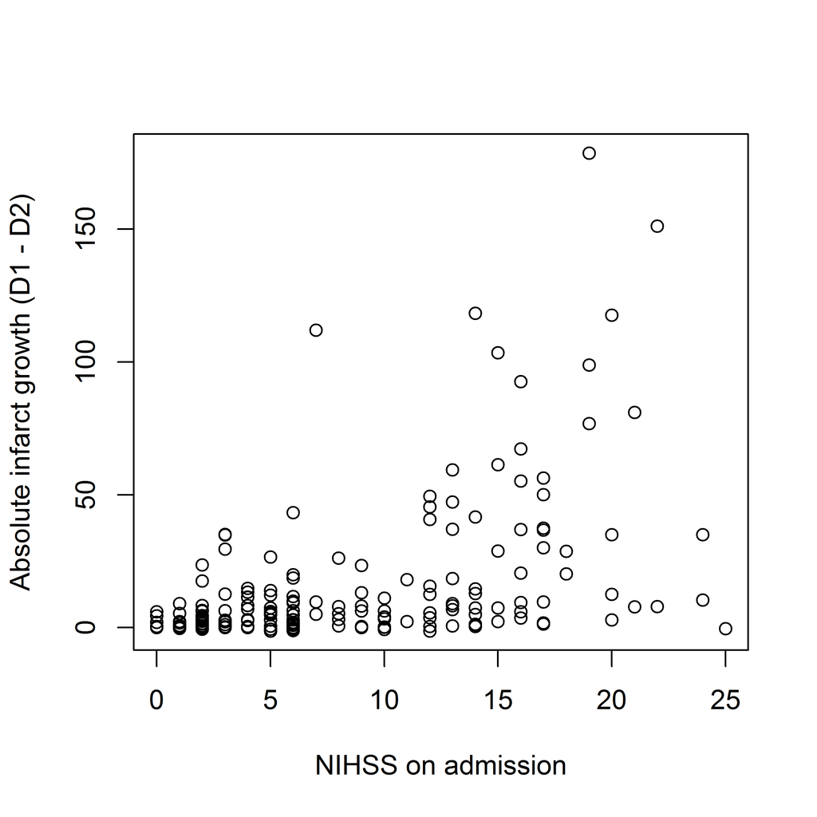

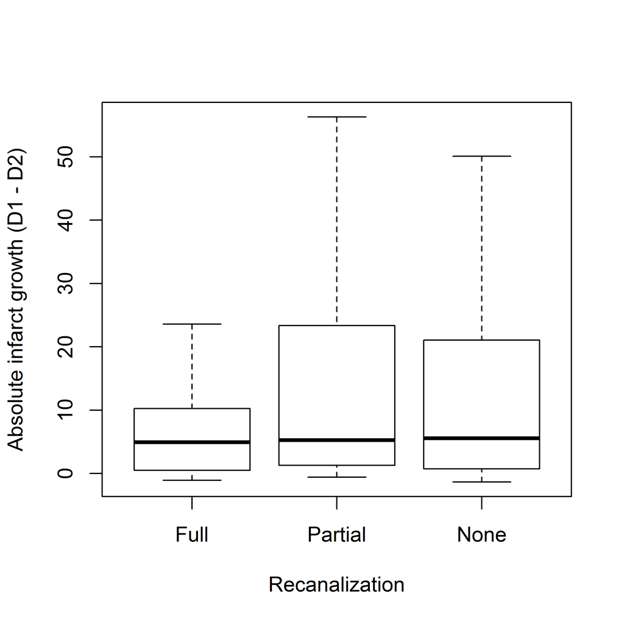

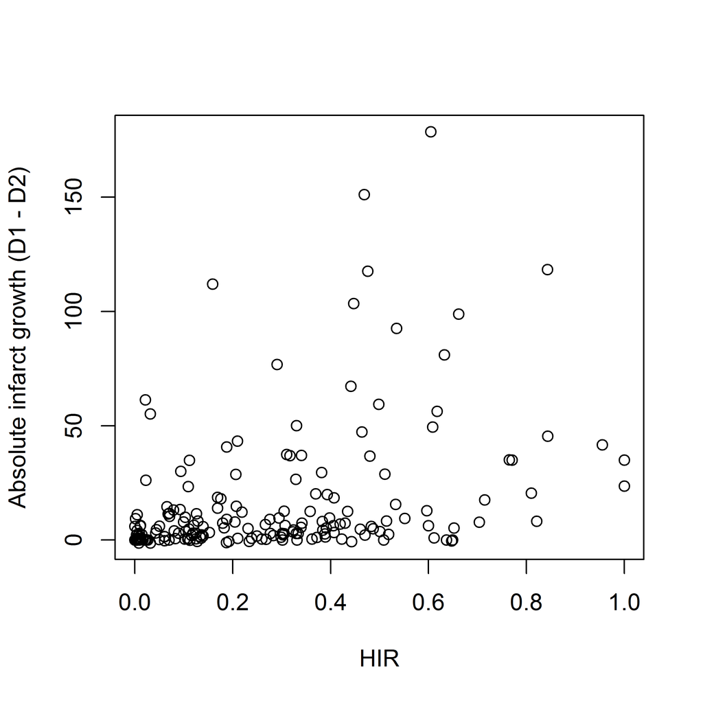

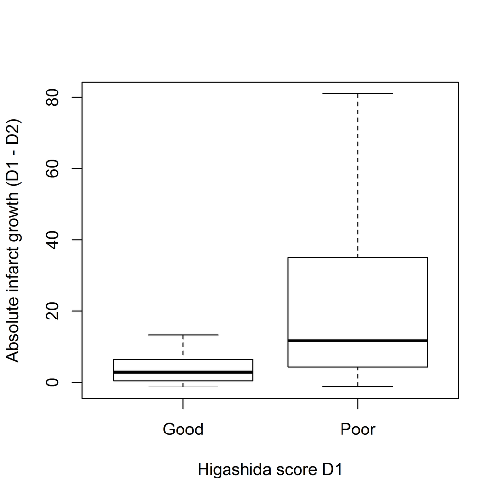

[output not shown]

**1 vs 2**

| Statistic | N | Mean | St. Dev. | Min | Max |
| --- | --- | --- | --- | --- | --- |
| pseudoDf | 2 | 174.000 | 2.828 | 172 | 176 |
| Test.Stat | 1 | 7.264 |  | 7.264 | 7.264 |
| Df | 1 | 4.000 |  | 4 | 4 |
| Pr(> chisq) | 1 | 0.123 |  | 0.123 | 0.123 |

**1 vs 3**

| Statistic | N | Mean | St. Dev. | Min | Max |
| --- | --- | --- | --- | --- | --- |
| pseudoDf | 2 | 173.500 | 3.536 | 171 | 176 |
| Test.Stat | 1 | 17.662 |  | 17.662 | 17.662 |
| Df | 1 | 5.000 |  | 5 | 5 |
| Pr(> chisq) | 1 | 0.003 |  | 0.003 | 0.003 |

**1 vs 4**

| Statistic | N | Mean | St. Dev. | Min | Max |
| --- | --- | --- | --- | --- | --- |
| pseudoDf | 2 | 173.500 | 3.536 | 171 | 176 |
| Test.Stat | 1 | 17.471 |  | 17.471 | 17.471 |
| Df | 1 | 5.000 |  | 5 | 5 |
| Pr(> chisq) | 1 | 0.004 |  | 0.004 | 0.004 |

### Predictors of absolute infarct growth (D1 - D5)

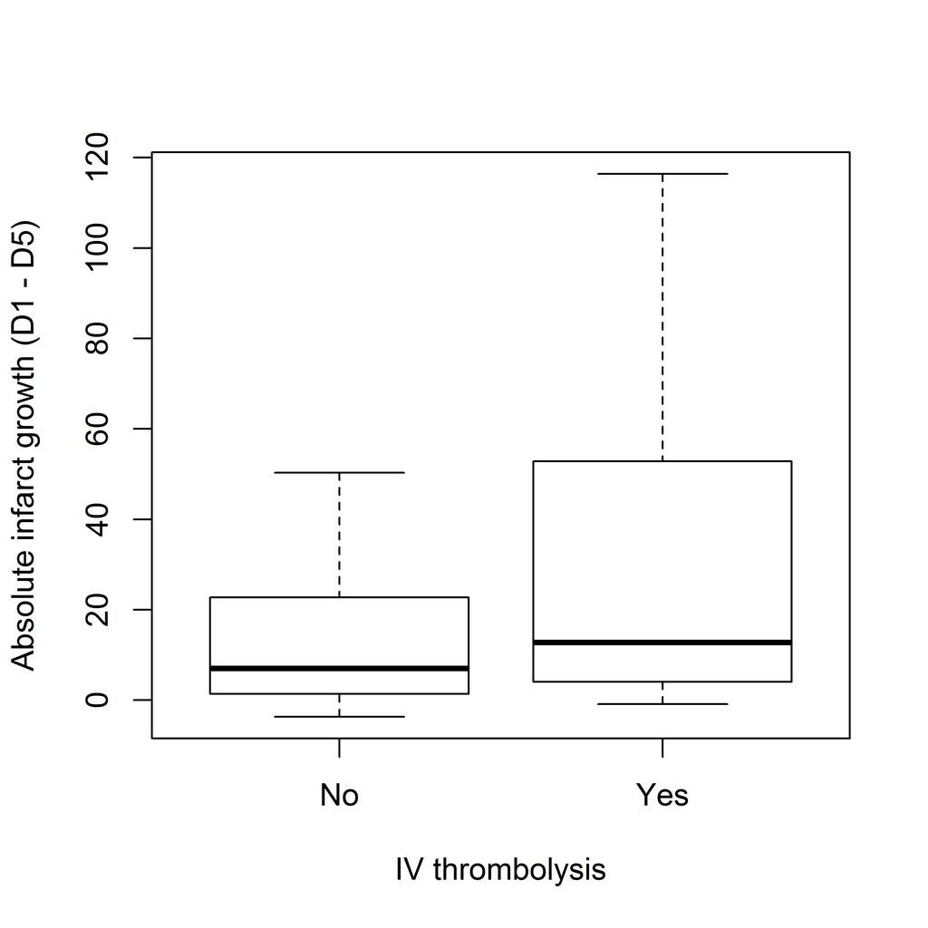

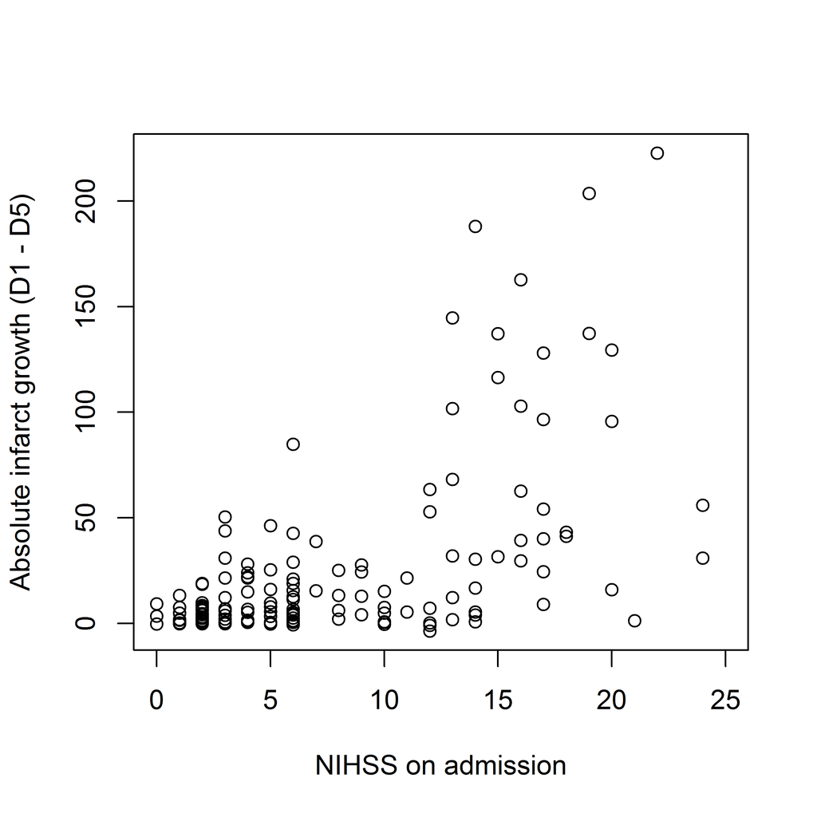

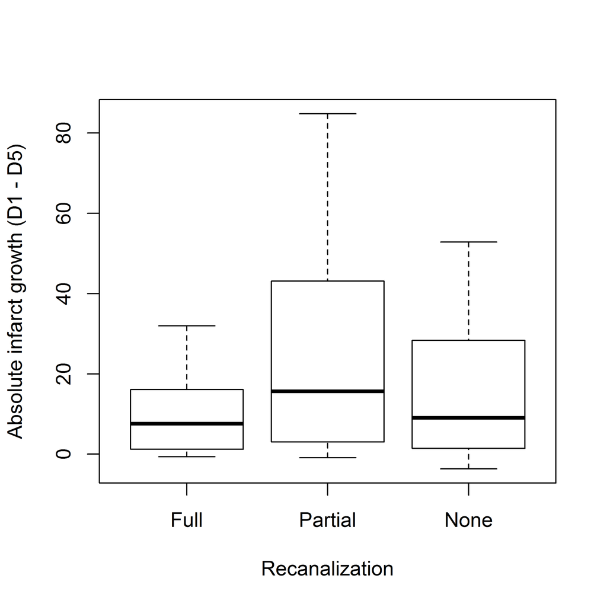

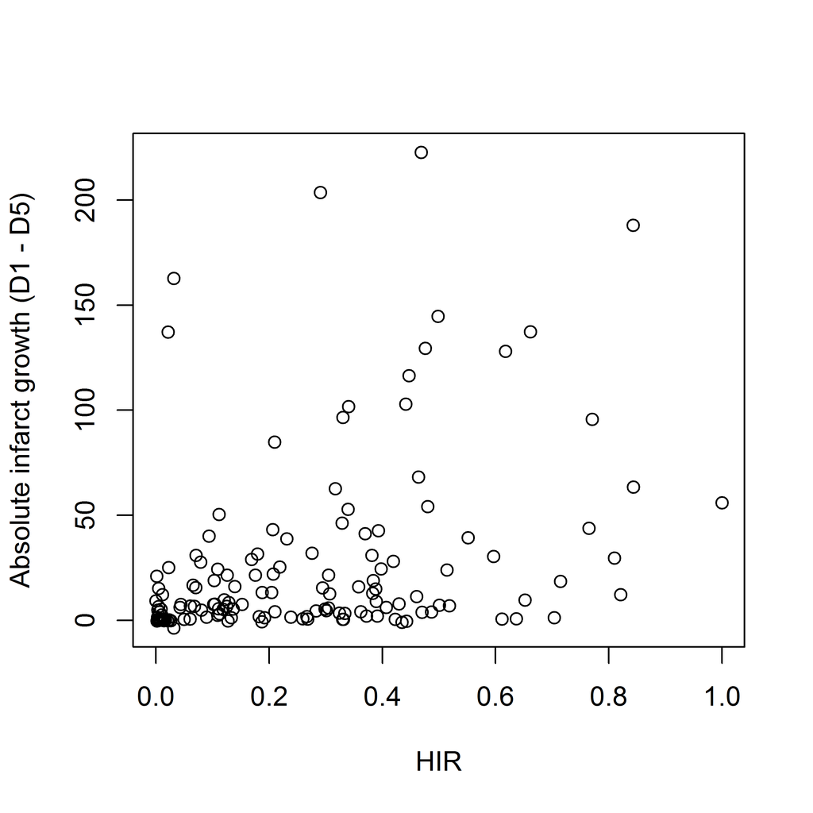

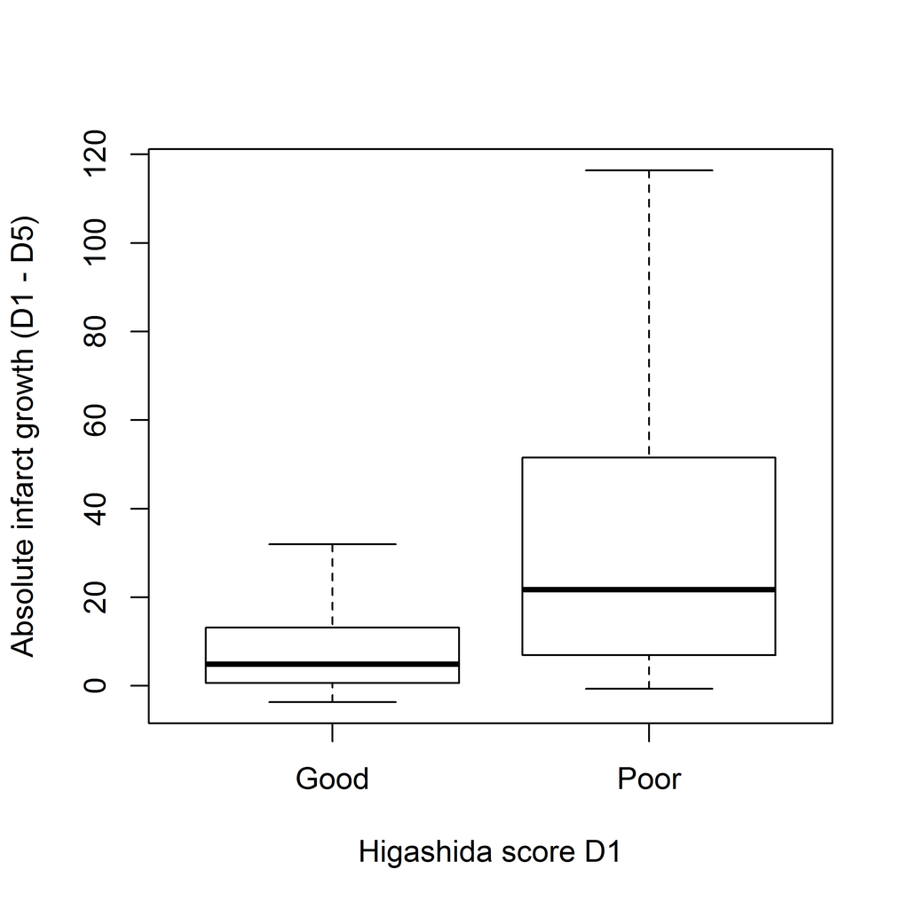

[output not shown]

**1 vs 2**

| Statistic | N | Mean | St. Dev. | Min | Max |
| --- | --- | --- | --- | --- | --- |
| pseudoDf | 2 | 132.000 | 2.828 | 130 | 134 |
| Test.Stat | 1 | 34.360 |  | 34.360 | 34.360 |
| Df | 1 | 4.000 |  | 4 | 4 |
| Pr(> chisq) | 1 | 0.00000 |  | 0.00000 | 0.00000 |

**1 vs 3**

| Statistic | N | Mean | St. Dev. | Min | Max |
| --- | --- | --- | --- | --- | --- |
| pseudoDf | 2 | 131.500 | 3.536 | 129 | 134 |
| Test.Stat | 1 | 8.672 |  | 8.672 | 8.672 |
| Df | 1 | 5.000 |  | 5 | 5 |
| Pr(> chisq) | 1 | 0.123 |  | 0.123 | 0.123 |

**1 vs 4**

| Statistic | N | Mean | St. Dev. | Min | Max |
| --- | --- | --- | --- | --- | --- |
| pseudoDf | 2 | 131.500 | 3.536 | 129 | 134 |
| Test.Stat | 1 | 18.365 |  | 18.365 | 18.365 |
| Df | 1 | 5.000 |  | 5 | 5 |
| Pr(> chisq) | 1 | 0.003 |  | 0.003 | 0.003 |

### Predictors of collateral flow defined by Higashida score

|  | *Dependent variable:* |  |
| --- | --- | --- |
|  | higashida_D1_bin |  |
|  | (1) | (2) |
| NIHSS_ad | 0.102*** (0.026) | 0.061** (0.028) |
|  | t = 3.964 | t = 2.148 |
|  | p = 0.0001 | p = 0.032 |
| HIR1 |  | 3.265*** (0.833) |
|  |  | t = 3.919 |
|  |  | p = 0.0001 |
| Constant | -1.008*** (0.262) | -1.552*** (0.318) |
|  | t = -3.842 | t = -4.889 |
|  | p = 0.0002 | p = 0.00001 |
| Observations | 186 | 186 |
| *Note:* | p<0.1; p<0.05; p<0.01 |  |

**1 vs 2**

| Statistic | N | Mean | St. Dev. | Min | Max |
| --- | --- | --- | --- | --- | --- |
| pseudoDf | 2 | 183.500 | 0.707 | 183 | 184 |
| Test.Stat | 1 | 15.360 |  | 15.360 | 15.360 |
| Df | 1 | 1.000 |  | 1 | 1 |
| Pr(> chisq) | 1 | 0.0001 |  | 0.0001 | 0.0001 |

### Predictors of collateral flow defined by HIR

|  | *Dependent variable:* |  |
| --- | --- | --- |
|  | HIR1 |  |
|  | (1) | (2) |
| NIHSS_ad | 0.016*** (0.002) | 0.013*** (0.002) |
|  | t = 6.778 | t = 5.125 |
|  | p = 0.000 | p = 0.00000 |
| higashida_D1_binPoor |  | 0.130*** (0.031) |
|  |  | t = 4.208 |
|  |  | p = 0.00005 |
| Constant | 0.121*** (0.025) | 0.092*** (0.025) |
|  | t = 4.894 | t = 3.661 |
|  | p = 0.00001 | p = 0.0004 |
| Observations | 186 | 186 |
| R<sup>2</sup> | 0.200 | 0.264 |
| Adjusted R<sup>2</sup> | 0.196 | 0.256 |
| Residual Std. Error | 0.204 (df = 184) | 0.196 (df = 183) |
| *Note:* | p<0.1; p<0.05; p<0.01 |  |

**1 vs 2**

| Statistic | N | Mean | St. Dev. | Min | Max |
| --- | --- | --- | --- | --- | --- |
| pseudoDf | 2 | 183.500 | 0.707 | 183 | 184 |
| Test.Stat | 1 | 17.707 |  | 17.707 | 17.707 |
| Df | 1 | 1.000 |  | 1 | 1 |
| Pr(> chisq) | 1 | 0.00003 |  | 0.00003 | 0.00003 |